# Untitled

## Всякі різні викладки

Лінійна регресія - метод відновлення залежності між цільовою змінною та іншими змінними. Лінійна означає, що цільова змінна виражається через рівняння наступного вигляду $y = ax + b + e = \hat{y} + e$, де $e$ - це похибка моделі.

Для початку вкажемо певні позначення, які далі нам трішки пригодяться:

$m$ - кількість об“єктів у вибірці;  
$n$ - кількість змінних;  
$y$ - цільова змінна;  
$\hat{y}$ - прогнозні значення цільової змінної;  
$X$ - змінні, за допомогою яких описується цільова змінна (перший стовбець складається із одиниць);  
$w$ - коефіцієнти при змінних;  
$y_i$ - значення цільової змінної для $i$-го об”єкту;  
$x_i$ - значення змінних для $i$-го об“єкту;

Запишемо всі наші позначення у матричному вигляді:

$$y = \begin{bmatrix}
y_1 \\
y_2 \\
\cdots \\
y_i \\
\cdots \\
y_m
\end{bmatrix}
,\:\:
\hat{y} = \begin{bmatrix}
\hat{y_1} \\
\hat{y_2} \\
\cdots \\
\hat{y_i} \\
\cdots \\
\hat{y_m}
\end{bmatrix}
,\:\:
X = \begin{bmatrix}
x_{11} & x_{12} & \cdots & x_{1n} \\
x_{21} & x_{22} & \cdots & x_{2n} \\
\cdots & \cdots & \cdots & \cdots \\
x_{i1} & x_{i2} & \cdots & x_{in} \\
\cdots & \cdots & \cdots & \cdots \\
x_{m1} & x_{m2} & \cdots & x_{mn} \\
\end{bmatrix} =
\begin{bmatrix}
1 & x_{12} & \cdots & x_{1n} \\
1 & x_{22} & \cdots & x_{2n} \\
\cdots & \cdots & \cdots & \cdots \\
1 & x_{i2} & \cdots & x_{in} \\
\cdots & \cdots & \cdots & \cdots \\
1 & x_{m2} & \cdots & x_{mn} \\
\end{bmatrix}
,\:\:
w = \begin{bmatrix}
{w_1} \\
{w_2} \\
\cdots \\
{w_n}
\end{bmatrix}$$

Запишемо рівняння лінійної регресії наступним чином:

$$y \approx \hat{y} = Xw$$

А тепер розпишемо більш детально, що означає попереднє рівняння, використовуючи правило множення матриць:

$$y \approx \hat{y} = \begin{bmatrix}
\hat{y_1} \\
\hat{y_2} \\
\cdots \\
\hat{y_i} \\
\cdots \\
\hat{y_m}
\end{bmatrix}
=
\begin{bmatrix}
x_{11} & x_{12} & \cdots & x_{1n} \\
x_{21} & x_{22} & \cdots & x_{2n} \\
\cdots & \cdots & \cdots & \cdots \\
x_{i1} & x_{i2} & \cdots & x_{in} \\
\cdots & \cdots & \cdots & \cdots \\
x_{m1} & x_{m2} & \cdots & x_{mn} \\
\end{bmatrix}
\begin{bmatrix}
{w_1} \\
{w_2} \\
\cdots \\
{w_n}
\end{bmatrix}
=
\begin{bmatrix}
x_{11}w_1 + x_{12}w_2 + \cdots + x_{1n}w_n \\
x_{21}w_1 + x_{22}w_2 + \cdots + x_{2n}w_n \\
\cdots \cdots \cdots \cdots \\
x_{i1}w_1 + x_{i2}w_2 + \cdots + x_{in}w_n \\
\cdots \cdots \cdots \cdots \\
x_{m1}w_1 + x_{m2}w_2 + \cdots + x_{mn}w_n \\
\end{bmatrix}$$

Позначимо через $e_i$ похибку між цільовою змінною та прогнозними значеннями лінійної регресії на $i$-му об“єкті:
$$e_i = y_i - \hat{y_i}$$

Визначимо функцію втрат як суму квадратів похибок між цільовою змінною та прогнозними значеннями на всіх об“єктах вибірки:
$$J(w) = \frac{1}{2m} \sum_{i = 1}^{m}e_i^2$$

Для зручності запишемо функцію втрат у векторній формі, яка, як показано далі, еквівадентна попередньому виразу:
$$J(w) = \frac{1}{2m} e^{T}e =
=
\frac{1}{2m}
\begin{bmatrix} e_1 & e_2 & \cdots & e_m \end{bmatrix}
\begin{bmatrix} e_1 \\ e_2 \\ \cdots \\ e_m \end{bmatrix}
=
\frac{1}{2m} (e_{1}e_{1} + e_{2}e_{2} + \cdots + e_{m}e_{m})
=
\frac{1}{2m} (e_{1}^2 + e_{2}^2 + \cdots + e_{m}^2)
=
\frac{1}{2m}\sum_{i = 1}^{m}e_i^2$$

Зробимо собі шпаргалку із властивостями матриць (те, що постійно забувається і необхідно весь час гуглити):

$(в1): (A + B)^{T} = A^{T} + B^{T}$  
$(в2): (AB)^{T} = B^{T}A^{T}$  
$(в3): (A^{T})^{T} = A$  
$(в4): a^{T}b = b^{T}a$  
$(в5): A^{-1}A = I$, де $I$ - одинична матриця

Розпишемо функцію втрат наступним чином:

$$J(w) = \frac{1}{2m} e^{T}e = \frac{1}{2m}(y - \hat{y})^{T}(y - \hat{y}) =\frac{1}{2m}(y - Xw)^{T}(y - Xw) = \\
використаємо \; правило \; (в1) \\
=\frac{1}{2m}(y^{\color{red}T} - (Xw)^{\color{red}T})(y - Xw) = \\
=\frac{1}{2m}(y^{T}y - y^{T}Xw - (Xw)^{T}y + (Xw)^{T}Xw) = \\
використаємо \; правило \; (в4) \\
=\frac{1}{2m}(y^{T}y - \color{red}{2(Xw)^{T}y} + (Xw)^{T}Xw) = \\
використаємо \; правило \; (в2) \\
=\frac{1}{2m}(y^{T}y - 2w^{\color{red}T}X^{\color{red}T}y + w^{\color{red}T}X^{\color{red}T}Xw)$$

Отже, функція втрат у матричній формі має наступний вигляд:

$$J(w) = \frac{1}{2m}(y^{T}y - 2w^{T}X^{T}y + w^{T}X^{T}Xw)$$

Щоб знайти параметри моделі $w$ необхідно взяти похідку від функції втрат $J(w)$ по вказаним параметрам, прирівняти її до нуля і розв“язати отримане рівняння відносно $w$.

Зробимо собі ще одну шпаргалку із правилами диференціювання матриць:

$(п1) : \frac{\partial}{\partial a}a^{T}b = b$  
$(п2) : \frac{\partial}{\partial a}a^{T}Ba = (B + B^{T})a$

Вызьмемо похідну від функції втрат по параметрам моделі:

$$\frac{\partial J(w)}{\partial w} =
\frac{\partial}{\partial w}[\frac{1}{2m}(y^{T}y - 2w^{T}X^{T}y + w^{T}X^{T}Xw)] =
\frac{1}{2m}[\frac{\partial}{\partial w}(y^{T}y) - 2\frac{\partial}{\partial w}(w^{T}X^{T}y) + \frac{\partial}{\partial w}(w^{T}X^{T}Xw)]$$

Розглянемо кожну похідну окремо:

$$\frac{\partial}{\partial w}(y^{T}y) = 0$$

Згідно правила (п1) маємо ($X^{T}y$ - вектор стовбець):
$$\frac{\partial}{\partial w}(w^{T}X^{T}y) = X^{T}y$$

Згідно правила (п2) маємо (нехай $X^{T}X$ - $B$):

$$\frac{\partial}{\partial w}(w^{T}X^{T}Xw) = (X^{T}X + (X^{T}X)^{T})w =
згідно \; правила \; (в2)
= (X^{T}X + X^{\color{red}T}(X^{T})^{\color{red}T})w =
згідно \; правила \; (в3)
= (X^{T}X + X^{T}X)w = 2X^{T}Xw$$

Отже:
$$\frac{\partial J(w)}{\partial w} = \frac{1}{2m}(0 - 2X^{T}y + 2X^{T}Xw) = \frac{1}{m}(X^{T}Xw - X^{T}y)$$

Для тогоб щоб знайти значення $w$, прирівняємо похідну до нуля:

$$\frac{1}{m}(X^{T}Xw - X^{T}y) = 0$$
$$X^{T}Xw - X^{T}y = 0$$

$$X^{T}Xw = X^{T}y$$

Використаємо правило (в5) і домножимо ліву і праву частину рівняння на $(X^{T}X)^{-1}$:
$$\color{red}{(X^{T}X)^{-1}}X^{T}Xw = \color{red}{(X^{T}X)^{-1}}X^{T}y$$

Звідси маємо значення параметрів моделі:

$$w = (X^{T}X)^{-1}X^{T}y$$

## Градієнтний спуск

Оскільки ось це $(X^{T}X)^{-1}X^{T}$ рахувати дуже затратно, особливо на великих даних, для отримання параметрів моделі можна використати алгоритм градієнтного спуску. Градієнт функції - це вектор із часткових похідних по її параметрах:
$$\bigtriangledown_{w} J(w) =
\begin{bmatrix}
\frac{\partial J(w)}{\partial w_1} \\
\frac{\partial J(w)}{\partial w_2} \\
\cdots \\
\frac{\partial J(w)}{\partial w_n}
\end{bmatrix}$$

Нам може допомогти властивість градієнта, яка говорить, що він вказує напрямок, в якому зростає функція. А нам необхідно знайти напрямок, в якому функція зменшується. Для цього поставимо знак мінус перед градієнтом (антиградієнт).

Формула розрахунку параметрів моделі буде мати наступний вигляд:

*Повторювати:*
$$w_{t} = w_{t-1} - \alpha \bigtriangledown_{w} J(w)$$
*Поки не зійдеться*
де $t$ номер ітерації алгоритму, $\alpha$ - “швидкість” навчання.

Розпишемо формулу:

$$w_{t} = w_{t-1} - \alpha \frac{\partial J(w)}{\partial w}$$

Похідну функції втрат по параметрах ми вже рахували вище:

$$w_{t} = w_{t-1} - \alpha \frac{1}{m}(X^{T}Xw - X^{T}y)$$

Винесемо $X^{T}$за дужки:

$$w_{t} = w_{t-1} - \alpha \frac{1}{m}(X^{T}(Xw - y))$$

## Всякі різні експерименти

Перейдемо до більш цікавого і спробуємо трішки попрацювати із формулами, які описувались вище, і даними.

```r
# завантажимо бібліотеки, які нам пригодяться
library(dplyr)           # для маніпуляції із даними
library(tidyr)           # для маніпуляції із даними
library(tibble)          # для маніпуляції із даними
library(purrr)           # для функціонального програмування
library(ggplot2)         # для гарних графіків
library(AmesHousing)     # тут лежать дані, які ми будемо використовувати
library(recipes)         # для всяких перетворень над даними
library(gganimate)       # для анімацій
library(broom)           # для акуратної роботи із вихідними результатами моделей
library(gt)              # для гарних табличок
```

Завантажимо дані по цінах на квартири:

```r
df <- AmesHousing::make_ames() %>%
  as_tibble()

# df
```

Для подальшої роботи використаємо як цільову змінну **Sale_Price**, а як залежну - **Lot_Area**. Для зручності перейменуємо їх як *target* = *Sale_Price*, *area* = *Lot_Area* і прологарифмуємо їх, щоб лінійна залежність між змінними була більш виражена:

```r
df_model <-
  df %>%
  select(target = Sale_Price, area = Lot_Area) %>%
  mutate_all(log)

# df_model
```

Подивимось на залежність ціни квартили від площі:

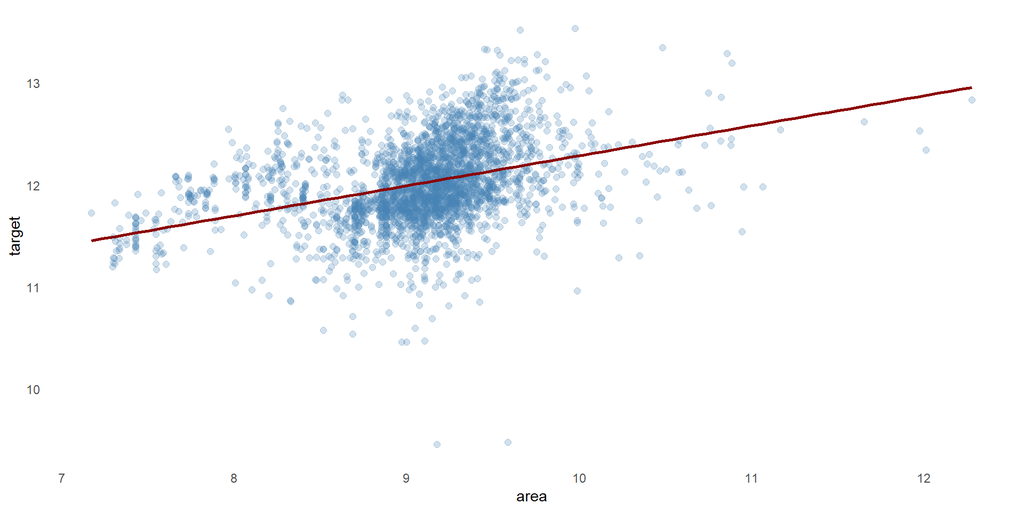

```r
p <-
  ggplot(df_model, aes(x = area, y = target)) +
  geom_point(alpha = 0.25, col = "steelblue", size = 2) +
  geom_smooth(se = FALSE, method = "lm", formula = y ~ x, col = "red4") +
  theme_minimal() +
  theme(panel.grid = element_blank())

p
```

Зробимо певні перетворення над змінною *area*: створимо *“рецепт”* (можна було б і більш простішим способом це зробити), щоб змінна мала більш стабільний розкид даних.

```r
# створюємо рецепт
rec <-
  recipe(
    target ~ area,
    data = df_model
  ) %>%
  step_center(area) %>%    # відняти середнє
  step_scale(area) %>%     # поділити на середньоквадратичне відхилення
  prep(retain = TRUE)

# отримуємо перетворені дані із рецепту
df_model <- juice(rec)

df_model
```

```
## # A tibble: 2,930 x 2
##      area target
##     <dbl>  <dbl>
##  1  2.49    12.3
##  2  0.525   11.6
##  3  0.926   12.1
##  4  0.446   12.4
##  5  0.865   12.2
##  6  0.227   12.2
##  7 -1.16    12.3
##  8 -1.12    12.2
##  9 -0.978   12.4
## 10 -0.332   12.1
## # ... with 2,920 more rows
```

Сформуємо вектор цільової змінної $y$ і матрицю змінних $X$, не забувши, звісно, додати стовбець із одиниць:

```r
Y <-
  df_model %>%
  select(target) %>%
  as.matrix()

dim(Y); head(Y)
```

```
## [1] 2930    1
```

```
##        target
## [1,] 12.27839
## [2,] 11.56172
## [3,] 12.05525
## [4,] 12.40492
## [5,] 12.15425
## [6,] 12.18332
```

```r
X <-
  df_model %>%
  select(area) %>%
  add_column(intercept = 1, .before = "area") %>%
  as.matrix()

dim(X); head(X)
```

```
## [1] 2930    2
```

```
##      intercept      area
## [1,]         1 2.4926105
## [2,]         1 0.5251899
## [3,]         1 0.9263526
## [4,]         1 0.4458299
## [5,]         1 0.8654902
## [6,]         1 0.2268022
```

Створимо модель лінійної регресії стандартними засобами за допомогою функції *lm()* та подивимось на її коефіцієнти:

```r
model_lm <- lm(target ~ area, data = df_model)

broom::tidy(model_lm) %>%
  select(term, estimate) %>%
  gt::gt()
```

| term | estimate |
| --- | --- |
| (Intercept) | 12.0209687 |
| area | 0.1501933 |

Тепер отримаємо коефіцієнти лінійної рейгресії за допомогою раніше виведеної формули $w = (X^{T}X)^{-1}X^{T}y$:

```r
# напишемо функцію отримання w
get_linear_coef <-
  function(
    x,   # матриця змінних
    y    # вектор цільової змінної
  ) {

    # solve() - отримати обернену матрицю
    # t()     - отримати транспоновану матрицю

    result <- solve(t(x) %*% x) %*% t(X) %*% y

    colnames(result) <- NULL
    return(result)
  }

# запускаємо функцію і бачимо, що ніби все зійшлося
coef <- get_linear_coef(x = X, y = Y)

coef %>%
  as.data.frame() %>%
  rownames_to_column(var = "term") %>%
  rename(estimate = V1) %>%
  gt::gt()
```

| term | estimate |
| --- | --- |
| intercept | 12.0209687 |
| area | 0.1501933 |

Напишемо функцію для отримання прогнозних значень $\hat{y}$;

```r
get_linear_pred <-
  function(
    x,
    coef
  ) {

    result <- x %*% coef

    return(result)

  }
```

Зробимо прогноз значень за допомогою стандартної моделі:

```r
bind_cols(
  tibble('Стандартна модель' = predict(model_lm, df_model)),
  get_linear_pred(x = X, coef = coef) %>%
  as_tibble() %>%
  rename('По формулі' = V1)
) %>%
    slice(1:5) %>%
    gt::gt()
```

| Стандартна модель | По формулі |
| --- | --- |
| 12.39534 | 12.39534 |
| 12.09985 | 12.09985 |
| 12.16010 | 12.16010 |
| 12.08793 | 12.08793 |
| 12.15096 | 12.15096 |

Як показано, ніби сходиться.

Напишемо функцію для обчислення функції втрат $J(w) = \frac{1}{2m} e^{T}e$:

```r
cost_func <-
  function(
    x,     # матриця із значеннями змінних
    y,     # вектор стовбець цільової змінної
    coef   # вектор стовбець коефіцієнтів моделі
  ) {

    m <- nrow(x)
    e <- y - x %*% coef

    result <- (1 / (2 * m)) * (t(e) %*% e)

    return(result)

  }
```

Напишемо функцію для обчислення градієнта функції втрат по параметрам моделі $\bigtriangledown_{w}J(w) = \frac{1}{m}(X^{T}(Xw - y))$

```r
gradient <-
  function(
    x,
    y,
    coef
  ) {
    m <- nrow(x)

    result <- (1 / m) * (t(x) %*% (x %*% coef - y))

    return(result)
  }
```

Нарешті, напишемо функцію для обчислення коефіцієнтів моделі градієнтним спуском:

```r
get_linear_coef_grad <-
  function(
    x,
    y,
    coef,
    count_iter = 100,
    alpha = 0.1
  ) {

    coef_list <- vector(mode = "list", length = count_iter)
    cost_list <- vector(mode = "list", length = count_iter)

    for (iter in 1:count_iter) {
      # оновлюємо параметри моделі
      coef <- coef - alpha * gradient(x = x, y = y, coef = coef)
      # обчислюємо функцію втрат для оновлених параметрів моделі
      cost <- cost_func(x = x, y = y, coef = coef)

      # збережемо все
      coef_list[[iter]] <- coef
      cost_list[[iter]] <- cost

    }

    cost_list <- map_dfr(
      .x = cost_list,
      .f = ~tibble(cost = .x)
    )

    coef_list <- map_dfr(
      .x = coef_list,
      .f = ~{
        .x %>% t() %>% as_tibble()
      }
    ) %>%
      rename_all(funs(paste0("w_", 1:nrow(coef))))

    # буде повертатись табличка із значеннями функції втрат і значеннями параметрів моделі на кожній ітерації
    result <- bind_cols(
      tibble(iteration = 1:count_iter),
      cost_list,
      coef_list
    )

    return(result)

  }
```

Отже, маючи всі необхідні інструменти прогонимо градієнтний спуск.

Спочатку ініціалізуємо параметри моделі:

```r
w <- matrix(data = -20, nrow = 2, ncol = 1)

w
```

```
##      [,1]
## [1,]  -20
## [2,]  -20
```

Запустимо градієнтний спуск на 100-а ітераціях із швидкістю навчання 0.1:

```r
iter_for_model <- 100
learning_rate <- 0.1

coef_grad <- get_linear_coef_grad(
  x = X,
  y = Y,
  coef = w,
  count_iter = iter_for_model,
  alpha = learning_rate
)

coef_grad
```

```
## # A tibble: 100 x 4
##    iteration  cost     w_1    w_2
##        <int> <dbl>   <dbl>  <dbl>
##  1         1 580.  -16.8   -18.0
##  2         2 470.  -13.9   -16.2
##  3         3 380.  -11.3   -14.5
##  4         4 308.   -8.99  -13.1
##  5         5 250.   -6.89  -11.8
##  6         6 202.   -5.00  -10.6
##  7         7 164.   -3.29   -9.49
##  8         8 133.   -1.76   -8.53
##  9         9 108.   -0.385  -7.66
## 10        10  87.1   0.856  -6.88
## # ... with 90 more rows
```

Відразу подивимось на коеціфієнти моделі на останній ітерації:

```r
coef_grad %>%
  filter(iteration == iter_for_model) %>%
  select(starts_with("w_")) %>%
  gt::gt()
```

| w_1 | w_2 |
| --- | --- |
| 12.02012 | 0.1496561 |

Здається отримали щось схоже на попередні значення.

Подивимось на графік зміни функції втрат в залежності від ітерації:

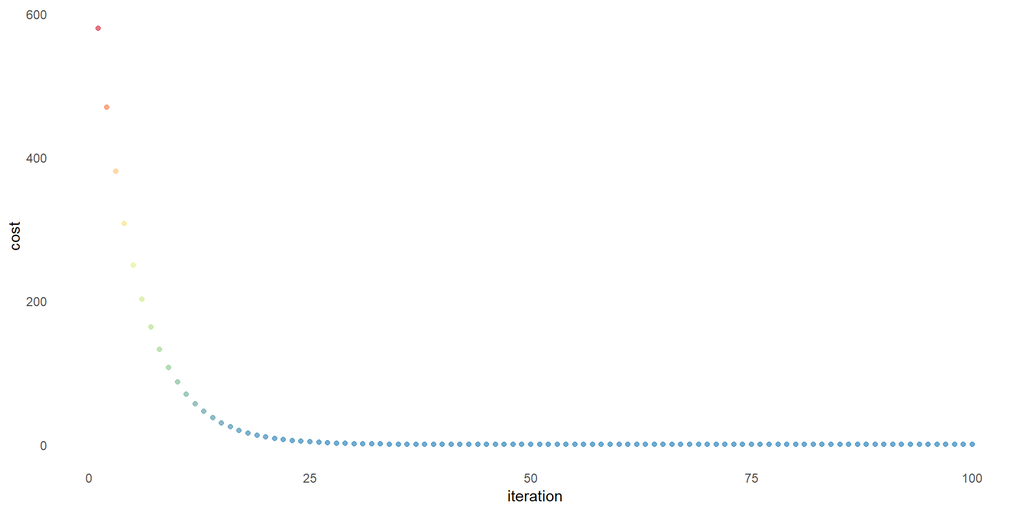

```r
plot_cost <- coef_grad %>%
  ggplot(aes(x = iteration, y = cost, col = cost)) +
  geom_point(alpha = 0.7, show.legend = FALSE) +
  scale_color_distiller(palette = "Spectral") +
  theme_minimal() +
  theme(panel.grid = element_blank())

plot_cost
```

Можна також подивитись як “рухались” параметри моделі до мінімуму функції втрат.

Створимо спочатку сітку із параметрів, для яких обчислимо функцію втрат:

```r
#
coef_grid <-
  expand.grid(
    w_1 = seq(-25, 25, length.out = 100),
    w_2 = seq(-25, 25, length.out = 100)
  )%>%
  as_tibble() %>%
  mutate(rownumb = row_number()) %>%
  group_by(rownumb) %>%
  nest() %>%
  mutate(
    cost = map(
      .x = data,
      .f = ~{
        coef <- matrix(c(.x$w_1, .x$w_2), nrow = 2, ncol = 1)
        cost_func(x = X, y = Y, coef = coef)
      }
    )
  ) %>%
  unnest()

coef_grid %>%
  slice(1:5) %>%
  gt::gt()
```

| rownumb | cost | w_1 | w_2 |
| --- | --- | --- | --- |
| 1 | 1001.5060 | -25.00000 | -25 |
| 2 | 982.9361 | -24.49495 | -25 |
| 3 | 964.6212 | -23.98990 | -25 |
| 4 | 946.5615 | -23.48485 | -25 |
| 5 | 928.7568 | -22.97980 | -25 |

Тепер побудуємо графік руху коефіцієнтів до мінімуму функції втрат:

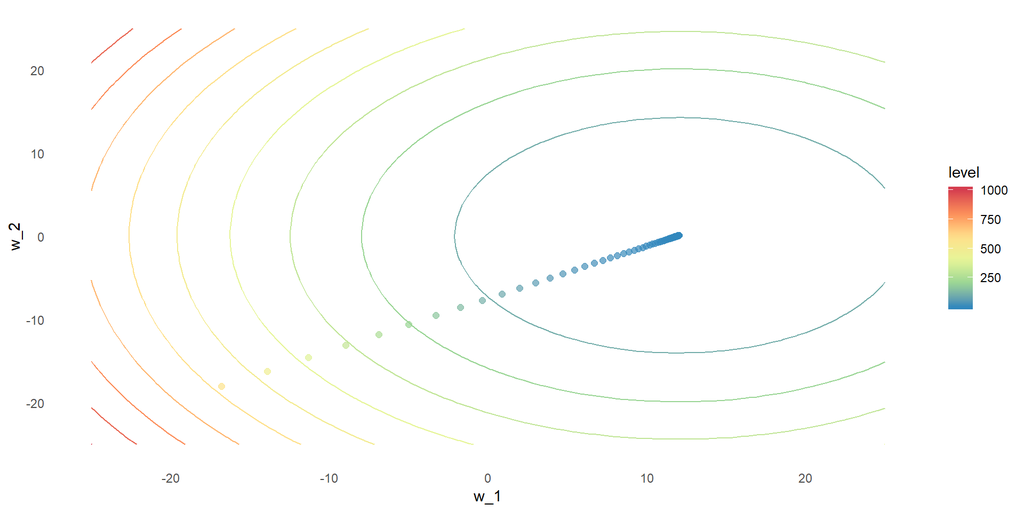

```r
plot_cost_coef <-
  ggplot() +
  geom_contour(
    data = coef_grid,
    aes(x = w_1, y = w_2, z = cost, colour = ..level..)
  ) +
  geom_point(
    data = coef_grad,
    aes(x = w_1, y = w_2, colour = cost),
    size = 2, alpha = 0.7
  ) +
  scale_color_distiller(palette = "Spectral") +
  theme_minimal() +
  theme(panel.grid = element_blank())

plot_cost_coef
```

Ось так ми і добрались до мінімуму функції втрат :)

Подивимось як змінювалась лінія регресії по ітераціях

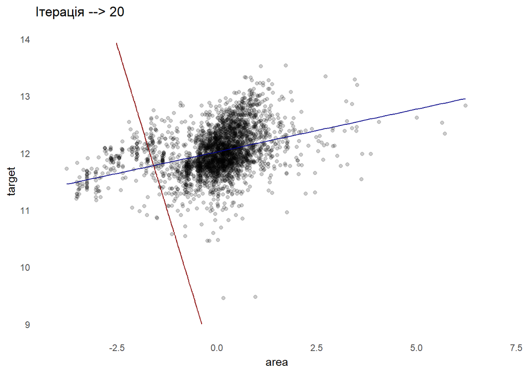

```r
# зробимо прогнози для параметрів моделі
coef_grad_pred <- coef_grad %>%
  filter(iteration %in% seq(20, 100, 5))%>%
  select(iteration, w_1, w_2) %>%
  group_by(iteration) %>%
  nest() %>%
  mutate(
    pred = map(
      .x = data,
      .f = ~{
        coef <- matrix(c(.x$w_1, .x$w_2), nrow = 2, ncol = 1)
        tibble(pred = as.vector(X %*% coef))
      }
    )
  ) %>%
  select(iteration, pred) %>%
  unnest()

# додамо реальні значення цільової змінної та предиктора
coef_grad_pred$target <- df_model$target
coef_grad_pred$area <- df_model$area
# glimpse(coef_grad_pred)

coef_grad_pred %>%
  ggplot() +
  geom_point(aes(x = area, y = target), alpha=  0.2) +
  geom_line(aes(x = area, y = pred), col = "red4", size = 0.5) +
  geom_smooth(aes(x = area, y = target), method = "lm", se = F, size = 0.5, col = "blue4") +
  scale_x_continuous(limits = c(-4, 7)) +
  scale_y_continuous(limits = c(9, 14)) +
  theme_minimal() +
  theme(panel.grid = element_blank()) +
  gganimate::transition_states(states = iteration) +
  ggtitle("Ітерація --> {closest_state}")
```

А можна ще подивитись як впливає швидкість навчання на функцію втрат:

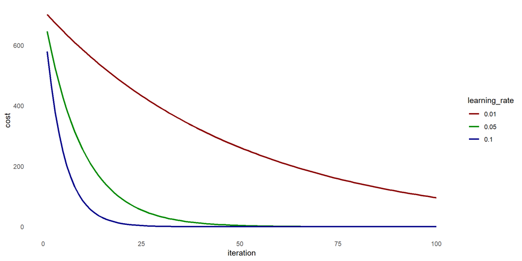

```r
# задамо сітку швидкості навчання і обчислимо параметри моделі
learning_rate_grid <- map_dfr(
  .x = c(0.1, 0.05, 0.01),
  .f = ~{
    get_linear_coef_grad(
      x = X,
      y = Y,
      coef = w,
      count_iter = iter_for_model,
      alpha = .x   # тут будуть змінюватись значення
    ) %>%
      mutate(learning_rate = .x)
  }
)

# намалюєио гарний графік
plot_alpha <-
  ggplot(
    data = learning_rate_grid,
    aes(x = iteration, y = cost, color = factor(learning_rate))
  ) +
  geom_line(size = 1) +
  scale_color_manual(values = c("red4", "green4", "blue4")) +
  labs(color = "learning_rate") +
  theme_minimal() +
  theme(panel.grid = element_blank())

plot_alpha
```

Як видно, чим менша швидкість, тим повільніше навчаємось.